# Mapping reads to scaffolds with BWA (Burrows-Wheeler Aligner) and sorting with Samtools

We now have seen the reads and the assembly with our own eyes. In any bio-informatic step, learn yourself always to have a peek into the actual data you are producing. Since you now have seen that the files look OK, we can start by mapping (aligning) the original reads in `.fastq.gz` files back to the scaffolds created with the assembly; the `scaffolds.fasta` file. Doing this will allow us to calculate the **depth on the scaffolds**; a prerequisite for the binning procedure.

Algning is achieved with bwa. Per sample, we map the reads against the scaffolds and save the mapping as a `.bam` file.

1. To run `bwa`, we first need to make an index file of the scaffolds.
2. Then we can run `bwa` and immediately pipe the output of `bwa` through `samtools view` which will output a `.bam` file .
3. Finally, since we have quite a few `.bam` files to align to the assembly, we will make a `for` loop that will iterate over the different samples we have.

Rember that the reads are paired-end Illumina sequences, which means that for each DNA fragment, we have sequence data from both ends. Therefore, the sequences are stored in two separate files (one for the data from each end). We'll use `bwa` with default settings to align the reads back to the scaffolds, and then `samtools` allows us to work with the bwa results.

**[Q:] Why this called back-mapping and not just mapping?**

**[A:]** We often call this back-mapping because we map the original reads used for the assembly, back to the original assembly.

**[Q:] Why do we not use the depth in the scaffold names?**

**⤷ Click here for a hint**

Remember that in the back-mapping step, we map, store and process all samples individually.

**[A:]** In the abundance graph we already say that when we look at abundance over all samples pooled, three bacteria are all equally abundant and indistinguisable without extra information. If we determine the abundance in all six samples individually, some microbes might be more present in one sample, and some more in another. Hence we will look at differential abundance over all samples for all contigs.

This differential abundance per bacterial genome can already be seen in an extended version the colourfull dot plot of the previous practical page. Here we look at 6 assemblies of the six individual samples.

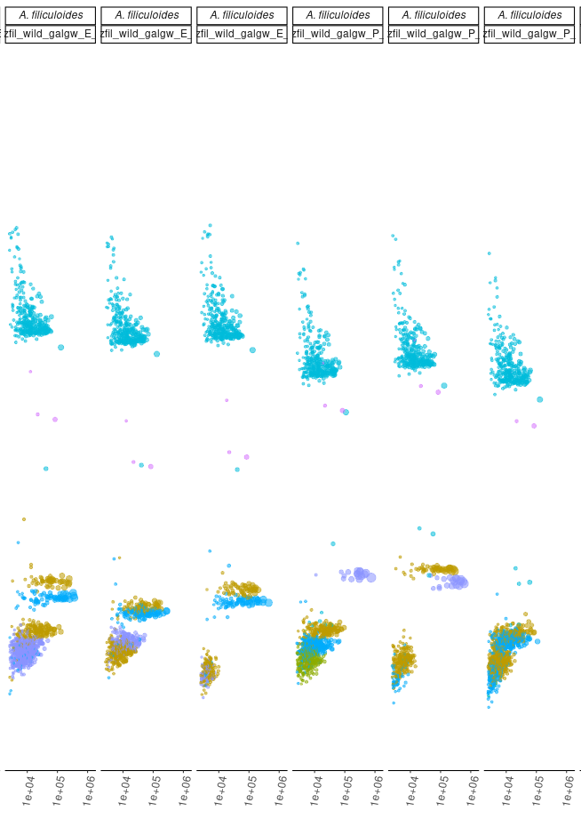

The next assignment is a complicated one. Make sure to read the instructions carefully and remember what you learned about bash loops earlier.

When in doubt, don't forget to read the 'help page' of a command like so:

> ls --help

or sometimes by executing the command without any arguments like so:

> bwa

> bwa index

For more elaborate information, read the manual with the `man` command. Unfortunately, this doesn't work well inside Jupyter notebooks.

> man bwa

> man samtools

## 1 Index the assembly with bwa index

**[DO:] Create an index of the scaffolds with** `bwa index`** Start by reading the `bwa index` instructions.

1. Remember to look for the 'usage' line first.
2. You won't need any options here.
3. Remember where the assembly was? We just gUnzipped it in the last notebook.
4. use `ls` and auto completion to find your way to the right file

```bash
bwa index
```

```
Usage:   bwa index [options] <in.fasta>

Options: -a STR    BWT construction algorithm: bwtsw, is or rb2 [auto]
         -p STR    prefix of the index [same as fasta name]
         -b INT    block size for the bwtsw algorithm (effective with -a bwtsw) [10000000]
         -6        index files named as <in.fasta>.64.* instead of <in.fasta>.*

Warning: `-a bwtsw' does not work for short genomes, while `-a is' and
         `-a div' do not work not for long genomes.
```

```bash
ls data/assembly
```

```
scaffolds.fasta  scaffolds.fasta.gz
```

```bash
bwa index ./data/assembly/scaffolds.fasta
```

```
[bwa_index] Pack FASTA... 0.61 sec
[bwa_index] Construct BWT for the packed sequence...
[BWTIncCreate] textLength=210601834, availableWord=26818708
[BWTIncConstructFromPacked] 10 iterations done. 44238506 characters processed.
[BWTIncConstructFromPacked] 20 iterations done. 81726650 characters processed.
[BWTIncConstructFromPacked] 30 iterations done. 115042122 characters processed.
[BWTIncConstructFromPacked] 40 iterations done. 144649002 characters processed.
[BWTIncConstructFromPacked] 50 iterations done. 170959642 characters processed.
[BWTIncConstructFromPacked] 60 iterations done. 194340570 characters processed.
[bwt_gen] Finished constructing BWT in 68 iterations.
[bwa_index] 61.56 seconds elapse.
[bwa_index] Update BWT... 0.51 sec
[bwa_index] Pack forward-only FASTA... 0.40 sec
[bwa_index] Construct SA from BWT and Occ... 31.49 sec
[main] Version: 0.7.17-r1188
[main] CMD: bwa index ./data/assembly/scaffolds.fasta
[main] Real time: 96.467 sec; CPU: 94.577 sec
```

While this runs, think about what is happening. Mapping always takes a query sequence and a reference sequence. The reference is our assembly, specifically the `scaffolds.fasta` file. What `bwa index` does, is take this reference and 'index' it. This means as much as it converts this regular text fasta file, into a binary format that computers can efficiently search.

## Check the output of bwa

After creating the index, there should be multiple files in the assembly folder. Think about what command you could use to see if that is the case. Use the empty cell below.

**[DO:] Check if the index files were created:**

```bash
ls data/assembly
```

```
scaffolds.fasta      scaffolds.fasta.bwt  scaffolds.fasta.sa
scaffolds.fasta.amb  scaffolds.fasta.gz
scaffolds.fasta.ann  scaffolds.fasta.pac
```

Besides the original scaffolds file, we now expect multiple other files. All of these together comprise the `index` we just made. A bwa index of a fasta file can be seen as a binary representation of the fasta file that bwa can search efficiently. It is not meant for human eyes, but purely for the computer algorithms to search through.

## Run bwa mem for backmapping

For this part, we will combine your skills on **bash loops** and **variables** to run bwa mem and samtools view on all the reads in data/reads and create BAM output files in a newly made directory.

Then we use a bash for loop to run samtools sort on all the files created by samtools view

Step by step instructions:

1. make a new directory for the samtools view results, give this a useful name
   1. I suggest ./data/mapped
   2. to make a directory, use the command `mkdir`
2. See how the loop I pre-made for you works, play a bit to see if you understand correctly
3. Don't forget to read the manual page of both! You can make extra cells to print these manual pages if you want to.
4. finish the for loop and run both these commands in a pipe
   1. `bwa mem`
   2. `samtools view`
5. bwa mem does not require any options,
6. For `samtools view`, look for the options to convert to a BAM file and write the output to a file.

It should look somewhat like this `bwa mem argument argument.fastq | samtools view argument argument`

If you forgot how a loop works, check the notebook of this morning' m1-jupyter_and_bash_basics.ipynb' .

Mapping each separate sample will take about 5 to 6 minutes. If you think your loop works (read: it doesn't crash immediately), then check in the next notebook if the files are created and if they increase in size. Use `ls -sh`.

**[DO:] 1 First make your new directory here:**

```bash
mkdir ./data/mapped
```

**[DO:] 2 now see how this loop works:**

```bash
# first I define the samples in a variable called 'samples'
samples=( L1 L2 L3 P1 P2 P3 )
# next I use this variable in my loop
for i in ${samples[@]}
    do echo $i
done
```

```
L1
L2
L3
P1
P2
P3
```

**[DO:] 3 Read the manual pages of bwa and samtools.** Remember to find the **usage** lines.

```bash
bwa mem
```

```
Usage: bwa mem [options] <idxbase> <in1.fq> [in2.fq]

Algorithm options:

       -t INT        number of threads [1]
       -k INT        minimum seed length [19]
       -w INT        band width for banded alignment [100]
       -d INT        off-diagonal X-dropoff [100]
       -r FLOAT      look for internal seeds inside a seed longer than {-k} * FLOAT [1.5]
       -y INT        seed occurrence for the 3rd round seeding [20]
       -c INT        skip seeds with more than INT occurrences [500]
       -D FLOAT      drop chains shorter than FLOAT fraction of the longest overlapping chain [0.50]
       -W INT        discard a chain if seeded bases shorter than INT [0]
       -m INT        perform at most INT rounds of mate rescues for each read [50]
       -S            skip mate rescue
       -P            skip pairing; mate rescue performed unless -S also in use

Scoring options:

       -A INT        score for a sequence match, which scales options -TdBOELU unless overridden [1]
       -B INT        penalty for a mismatch [4]
       -O INT[,INT]  gap open penalties for deletions and insertions [6,6]
       -E INT[,INT]  gap extension penalty; a gap of size k cost '{-O} + {-E}*k' [1,1]
       -L INT[,INT]  penalty for 5'- and 3'-end clipping [5,5]
       -U INT        penalty for an unpaired read pair [17]

       -x STR        read type. Setting -x changes multiple parameters unless overridden [null]
                     pacbio: -k17 -W40 -r10 -A1 -B1 -O1 -E1 -L0  (PacBio reads to ref)
                     ont2d: -k14 -W20 -r10 -A1 -B1 -O1 -E1 -L0  (Oxford Nanopore 2D-reads to ref)
                     intractg: -B9 -O16 -L5  (intra-species contigs to ref)

Input/output options:

       -p            smart pairing (ignoring in2.fq)
       -R STR        read group header line such as '@RG\tID:foo\tSM:bar' [null]
       -H STR/FILE   insert STR to header if it starts with @; or insert lines in FILE [null]
       -o FILE       sam file to output results to [stdout]
       -j            treat ALT contigs as part of the primary assembly (i.e. ignore <idxbase>.alt file)
       -5            for split alignment, take the alignment with the smallest coordinate as primary
       -q            don't modify mapQ of supplementary alignments
       -K INT        process INT input bases in each batch regardless of nThreads (for reproducibility) []

       -v INT        verbosity level: 1=error, 2=warning, 3=message, 4+=debugging [3]
       -T INT        minimum score to output [30]
       -h INT[,INT]  if there are <INT hits with score >80% of the max score, output all in XA [5,200]
       -a            output all alignments for SE or unpaired PE
       -C            append FASTA/FASTQ comment to SAM output
       -V            output the reference FASTA header in the XR tag
       -Y            use soft clipping for supplementary alignments
       -M            mark shorter split hits as secondary

       -I FLOAT[,FLOAT[,INT[,INT]]]
                     specify the mean, standard deviation (10% of the mean if absent), max
                     (4 sigma from the mean if absent) and min of the insert size distribution.
                     FR orientation only. [inferred]

Note: Please read the man page for detailed description of the command line and options.
```

```bash
samtools view
```

```
Usage: samtools view [options] <in.bam>|<in.sam>|<in.cram> [region ...]

Options:
  -b       output BAM
  -C       output CRAM (requires -T)
  -1       use fast BAM compression (implies -b)
  -u       uncompressed BAM output (implies -b)
  -h       include header in SAM output
  -H       print SAM header only (no alignments)
  -c       print only the count of matching records
  -o FILE  output file name [stdout]
  -U FILE  output reads not selected by filters to FILE [null]
  -t FILE  FILE listing reference names and lengths (see long help) [null]
  -X       include customized index file
  -L FILE  only include reads overlapping this BED FILE [null]
  -r STR   only include reads in read group STR [null]
  -R FILE  only include reads with read group listed in FILE [null]
  -d STR:STR
           only include reads with tag STR and associated value STR [null]
  -D STR:FILE
           only include reads with tag STR and associated values listed in
           FILE [null]
  -q INT   only include reads with mapping quality >= INT [0]
  -l STR   only include reads in library STR [null]
  -m INT   only include reads with number of CIGAR operations consuming
           query sequence >= INT [0]
  -f INT   only include reads with all  of the FLAGs in INT present [0]
  -F INT   only include reads with none of the FLAGS in INT present [0]
  -G INT   only EXCLUDE reads with all  of the FLAGs in INT present [0]
  -s FLOAT subsample reads (given INT.FRAC option value, 0.FRAC is the
           fraction of templates/read pairs to keep; INT part sets seed)
  -M       use the multi-region iterator (increases the speed, removes
           duplicates and outputs the reads as they are ordered in the file)
  -x STR   read tag to strip (repeatable) [null]
  -B       collapse the backward CIGAR operation
  -?       print long help, including note about region specification
  -S       ignored (input format is auto-detected)
  --no-PG  do not add a PG line
      --input-fmt-option OPT[=VAL]
               Specify a single input file format option in the form
               of OPTION or OPTION=VALUE
  -O, --output-fmt FORMAT[,OPT[=VAL]]...
               Specify output format (SAM, BAM, CRAM)
      --output-fmt-option OPT[=VAL]
               Specify a single output file format option in the form
               of OPTION or OPTION=VALUE
  -T, --reference FILE
               Reference sequence FASTA FILE [null]
  -@, --threads INT
               Number of additional threads to use [0]
      --write-index
               Automatically index the output files [off]
      --verbosity INT
               Set level of verbosity
```

**[DO:] Map the paired-end reads of each sample to the index scaffolds and save the output as a** `.bam` **file.**

```bash
# first I define the samples in a variable called 'samples'
samples=( L1 L2 L3 P1 P2 P3 )
# next I use this variable in my loop
for i in ${samples[@]}
    do bwa mem data/assembly/scaffolds.fasta data/reads/$i.R1.fastq.gz data/reads/$i.R2.fastq.gz | samtools view -b -o data/mapped/$i.bam
done
```

[output not shown]

[output cut: 2262 more lines]

```
[M::mem_pestat] skip orientation RR as there are not enough pairs
[M::mem_process_seqs] Processed 66708 reads in 10.190 CPU sec, 10.043 real sec
[M::mem_pestat] # candidate unique pairs for (FF, FR, RF, RR): (1, 17109, 9, 3)
[M::mem_pestat] skip orientation FF as there are not enough pairs
[M::mem_pestat] analyzing insert size distribution for orientation FR...
[M::mem_pestat] (25, 50, 75) percentile: (455, 532, 602)
[M::mem_pestat] low and high boundaries for computing mean and std.dev: (161, 896)
[M::mem_pestat] mean and std.dev: (526.37, 112.95)
[M::mem_pestat] low and high boundaries for proper pairs: (14, 1043)
[M::mem_pestat] skip orientation RF as there are not enough pairs
[M::mem_pestat] skip orientation RR as there are not enough pairs
[M::mem_process_seqs] Processed 65152 reads in 9.829 CPU sec, 9.783 real sec
[main] Version: 0.7.17-r1188
[main] CMD: bwa mem data/assembly/scaffolds.fasta data/reads/P3.R1.fastq.gz data/reads/P3.R2.fastq.gz
[main] Real time: 298.032 sec; CPU: 302.234 sec
```

TIP: If you are working on your own computer and not some shared server, you can speed up the process substantially by using more threads (CPUs/cores) to do the mapping. Find the amount of cores available on your computer with `nproc` and read the bwa manual to use more threads.

**[DO:] If the loop is running, then proceed to the next notebook.** Check with `ls` if your files are being created and perhaps if they increase in size over time. Then start preparing the next loop: sorting of the bam files.

Some background:

> By default, mapping algorithms like bwa spit out a .sam file. The sam format is widely used and accepted by many different downstream programmes. Basically, it's just a big table with a standardised format. Although a sam file is human-readable, it is also rather bulky. The file size of a single SAM file will quickly exceed the disk space you have on this virtual machine. Therefore, we convert it to a BAM file, a Binary sAM file. There is no loss of information; it is just saved much more efficiently. Naturally, a binary file is not human readable. Always store your files as bam files. If you need to have a look in the bam file, you can view them using `samtools view` or any of the many downstream programmes available online.